LAMA Lab No. 1: Data Preparation Task

# Introduction

*"Machine Learning at its most basic is the practice of using algorithms to parse data, learn from it, and then make a determination or prediction about something in the world." -- Nvidia (Source: https://emerj.com/ai-glossary-terms/what-is-machine-learning/)*

Well, as you might already heard machine learning is based on data. Basically machine learning algorithms use many data samples to find a generalized solution to a given problem, once unknown or new data is used. Therefore, an important task in the beginning is proper data preparation.

Hence you will learn in the first part of this session how data is read from files. The proper data handling is then discussed. In the next part you learn how to use and utilize your data in order to get the most out of your machine learning approach.

## Load Data from CSV

**First of all let's see what a CSV is.**

A very common file format for data are CSV files. CSV is short for **C**omma **S**eparated **V**alues. A CSV file is constructed out of rows and columns, similar to a table. Columns are separated by commas (,) and each line in the file represents a row.

## Tutorial

As mentioned in the introduction, you will now see how to load a file and convert the input data into data types (such as integers, floats, strings etc...), which can be handled by Python. This provides you the basic knowledge on how to load data.

For CSV files we can use a python standard library, which contains a `reader()` function. This function takes a file as input argument and returns a list of data rows.

Let's get started with the code and create a function called `load_csv()`, which will take the filename as an argument and returns the dataset.

During this session we use a diabetes dataset provided by the National Institute of Diabetes and Digestive and Kidney Diseases.

"The objective of the dataset is to diagnostically predict whether or not a patient has diabetes, based on certain diagnostic measurements included in the dataset. Several constraints were placed on the selection of these instances from a larger database. In particular, all patients here are females at least 21 years old of Pima Indian heritage." -- (https://www.kaggle.com/uciml/pima-indians-diabetes-database)

**Task: complete the given `load_csv()` function**

Hint: It will be tested afterwards in the next code box

```python
from csv import reader

# Load a CSV file

    ### STUDENT CODE HERE
def load_csv(filename):
    with open(filename,"r") as csv_file:
        dataset = list(reader(csv_file, delimiter=','))


    ### STUDENT CODE until HERE

    return dataset
```

If we look at the structure of the data, we can see, that it is numeric data, which is seperated by commas (,) (see picture below). Let's use our written function to learn about some details of the data like the number of rows and used columns.

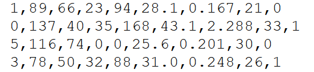

**Task: use your function and complete the print statement in order to output the number of rows and columns in your dataset**

```python
filename = 'data\pima-indians-diabetes.csv'

### STUDENT CODE HERE
dataset = load_csv(filename)



a = len(dataset)
b = len(dataset[0])



### STUDENT CODE until HERE



print('Loaded data file {0} with {1} rows and {2} columns'.format(filename, a , b) )###
```

```
Loaded data file data\pima-indians-diabetes.csv with 768 rows and 9 columns
```

Actually, there is a small problem with our function, since it will load empty lines from the data file and add them to our list of rows. We can handle this case if we are adding only rows with data to the dataset list, while skipping empty rows.

**Task: Write a improved function for `load_csv()`, which skips empty rows.**

```python
from csv import reader
filename = 'data\pima-indians-diabetes.csv'
def load_csv(filename):

    ### STUDENT CODE HERE
    with open(filename,"r") as csv_file:
        dataset = list(reader(csv_file, delimiter=','))
        dataset_1 = []


        for list_temp in range(len(dataset)):
            if len(dataset[list_temp]) == 0 :# find empty function
                print("Row", list_temp, "is empty.")

            else:
                dataset_1.append(dataset[list_temp])
    return dataset
    ### STUDENT CODE until HERE

# Test your new function...
dataset = load_csv(filename)
print('Loaded data file {0} with {1} rows and {2} columns'.format(filename, len(dataset),len(dataset[0])))
```

```
Loaded data file data\pima-indians-diabetes.csv with 768 rows and 9 columns
```

## Convert Strings to Floats

The majority of all machine learning algorithms prefer to work with numbers, especially floating point numbers. But does our current code for loading a csv file even satisfy this demand? Let's check it by printing one line of data.

```python
print(dataset[0])
print(dataset.__class__.__name__)    # This python magic variable (also called special attribute) gives information about the datatype
print(dataset[0].__class__.__name__) # Further reading: https://docs.python.org/3/library/stdtypes.html#special-attributes
print(dataset[0][0].__class__.__name__)
```

```
['6', '148', '72', '35', '0', '33.6', '0.627', '50', '1']
list
list
str
```

Our current code for loading a CSV file returns a list of lists with each value being a string (str). As you might guess, now is the time to convert the strings to a floating point number.

**Task: Create a function called `str_column_to_float`. It takes your dataset and the index of a column as input and returns the converted one.**

Hint: strip any whitespace from the value before making the conversion. To make your code "pythonic" and faster, please try to use list comprehensions (Further reading: https://towardsdatascience.com/how-list-comprehensions-can-help-your-code-look-better-and-run-smoother-3cf8f87172ae) from the beginning on :).

```python
def str_column_to_float(dataset, column):
    ### STUDENT CODE HERE

    for rows in range(len(dataset)):
        dataset[rows][column] = float(dataset[rows][column])
    return dataset

    ### STUDENT CODE until HERE
```

Now if we add this function to our previous code we can test if it is working correctly:

```python
print(dataset[0])

# convert string columns to float
for i in range(len(dataset[0])):
    str_column_to_float(dataset, i)


print(dataset[0])
```

```
['6', '148', '72', '35', '0', '33.6', '0.627', '50', '1']
[6.0, 148.0, 72.0, 35.0, 0.0, 33.6, 0.627, 50.0, 1.0]
```

## Convert String to Integers

Now that you know how to convert strings to floats, we learn how to convert strings to integers. This might seem to be a little bit unnecessary, but to show you that there are cases in which you might prefer to have integers instead of strings we use a different training set.

The new dataset is called "iris.csv". You can find it in the "data" folder. Also you can find more information here: http://archive.ics.uci.edu/ml/datasets/Iris

If we now take a small peek into our dataset, we see that there is numeric and character data. In the final column, which is commonly reserved to hold the outcome or the predicted value for a row, is a string.

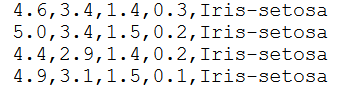

We can convert the class value to an integer by creating a map. To do so, we take a closer look at the data and see that there are only the following values: "Iris-setsosa", "Iris-versicolor" and "Iris-virginica". The next step, is to assign each class an integer value, like: 0,1,2. In the end the value "Iris-setsosa" is assigned to value 0 and so on...

**Task: Create a function, which first of all extract all possible values for a given column and then assigns numbers to this column.**

Your function takes the dataset and the column id as input and returns both the lookup table (a map of the possible values and the corresponding integer values) and the changed dataset

Hint: Take a look at the build-in set() constructor and the dict() constructor for the structure of the lookup table.

```python
# Convert string column to integer

def str_column_to_int(dataset, column):

   ### STUDENT CODE HERE
    set_column = set()
    for h in range(len(dataset)):
        set_column.add(dataset[h][column])

    lookup = {}
    for m in range(len(set_column)):
        lookup[m] = list(set_column)[m]
        #lookup[list(set_column)[m]] = m --> depending on which direction the lookup table is supposed to function

    for k in range(len(dataset)):
        dataset[k][column] = list(lookup.keys())[list(lookup.values()).index(dataset[k][column])]
        #dataset[k][column] = lookup.get(dataset[k][column]) - function for lookup[list(set_column)[m]] = m

    ### STUDENT CODE until HERE

    return lookup, dataset

#str_column_to_int(dataset, 4)
```

At the end of this chapter, we want to use everything we learned so far and see if it works all together. Load the Iris Data Set and convert the first three columns to floats and the last one to an integer. Make sure your output explains the converted strings.

```python
# Load iris dataset
filename = 'data/iris.csv'

### STUDENT CODE HERE
# please run load_csv with skipping empty rows
dataset = load_csv(filename)

print('Loaded data file {0} with {1} rows and {2} columns'.format(filename, len(dataset),len(dataset[0])))
print('Original data row: {}'.format(dataset[0]))

dataset = [x for x in dataset if x != []]

# convert string columns to float
for i in range(4):
    str_column_to_float(dataset, i)

# convert class column to int
lookup, dataset = str_column_to_int(dataset, 4)

print('Modified data row: {}'.format(dataset[0]))
print('Lookup table: {}'.format(lookup))

### STUDENT CODE HERE
```

[output not shown]

## Further information on CSV files

Before you load your data, you want to get a glimpse behind the curtain, to see the shape of your data. It is important to check your dataset for the following points.

Does your dataset have file headers? This might be useful to automatically assign attributes/features to each column of data. If not, you might want to consider to name your attributes manually.

In the next step you should check your data for comments. These are indicated in CSV-files with a # at the start of a line. It depends on the method with witch you load your dataset, but you might need to indicate, that there might occur some comments in your data.

If your data does use a tab or white space instead of a comma you should also specify this explicitly. Moreover in some CSV files values are quoted with the double quotation mark character (e.g. if your data itself contains commas). If your file differs from that, you also should specify the quote character used in your data.

Please have a look at the following code and take a look at the parameters, which are passed to the `csv.reader` call.

```python
# Load CSV Using Python Standard Library
import csv

filename = 'data/pima-indians-diabetes.csv'

raw_data = open(filename, 'rt')
reader = csv.reader(raw_data, delimiter=',', quoting=csv.QUOTE_NONE)

rows = list(reader)
print(rows[0])
```

```
['6', '148', '72', '35', '0', '33.6', '0.627', '50', '1']
```

## Load CSV-Files with Pandas

In order to load CSV-files in an efficient way in many cases you want to use the `pandas` python package using the function `pandas.read_csv()` (https://pandas.pydata.org/pandas-docs/stable/reference/api/pandas.read_csv.html#pandas.read_csv). This function is very flexible and returns a pandas dataframe object, which you can use for summarizing and plotting directly.

Please have a look at the following code to see how pandas can be used to read data. Please note, that the `read_csv` function is able to also take the column "names".

```python
from pandas import read_csv

filename = 'data/pima-indians-diabetes.csv'

names = ['preg', 'plas', 'pres', 'skin', 'test', 'mass', 'pedi', 'age', 'class'] # column names
data = read_csv(filename, names=names)

print(data.shape) # Get the columns and rows. Format:(rows, cols)
```

```
(768, 9)
```

# Understand Your Data With Descriptive Statistics

Now that you know how to load your data we want to give you some tools on how to get a quick overview over your data so you can decide how you can get the most out of it.

You can either take a look at the data by opening it, or you can use the pandas package, which offers you a function to give you a peek into the raw data. To do so use the `head()` function.

**Task: Write a piece of code, which shows you the first 20 rows of your data. For this you can directly use the data object from above**

```python
### STUDENT CODE HERE
peek = data.head(n=20)

### STUDENT CODE until HERE

print(peek)
```

```
    preg  plas  pres  skin  test  mass   pedi  age  class
0      6   148    72    35     0  33.6  0.627   50      1
1      1    85    66    29     0  26.6  0.351   31      0
2      8   183    64     0     0  23.3  0.672   32      1
3      1    89    66    23    94  28.1  0.167   21      0
4      0   137    40    35   168  43.1  2.288   33      1
5      5   116    74     0     0  25.6  0.201   30      0
6      3    78    50    32    88  31.0  0.248   26      1
7     10   115     0     0     0  35.3  0.134   29      0
8      2   197    70    45   543  30.5  0.158   53      1
9      8   125    96     0     0   0.0  0.232   54      1
10     4   110    92     0     0  37.6  0.191   30      0
11    10   168    74     0     0  38.0  0.537   34      1
12    10   139    80     0     0  27.1  1.441   57      0
13     1   189    60    23   846  30.1  0.398   59      1
14     5   166    72    19   175  25.8  0.587   51      1
15     7   100     0     0     0  30.0  0.484   32      1
16     0   118    84    47   230  45.8  0.551   31      1
17     7   107    74     0     0  29.6  0.254   31      1
18     1   103    30    38    83  43.3  0.183   33      0
19     1   115    70    30    96  34.6  0.529   32      1
```

In the first chapter you learned how to convert different data types. But before you can convert different datatypes you have to to know which datatypes you are currently working on. The `dtypes` function from the pandas tells you the datatype of each column.

```python
# datatype of each column
types = data.dtypes
print(types)
```

```
preg       int64
plas       int64
pres       int64
skin       int64
test       int64
mass     float64
pedi     float64
age        int64
class      int64
dtype: object
```

## Descriptive Statistics

Now that we have the big picture in terms of its shape, the first lines and the datatypes of our raw data, we might also want to gain information about their attributes. The question her is what is hidden behind the different values. This also gives you the ability to estimate whether your algorithm is working correctly in the end.

The `describe` function lists 8 statistical properties of each attribute:

*count, mean, Standard Deviation, Minimum Value, 25th Percentile, 50th Percentile (Median), 75 Percentile and Maximum Value*

**Task: Use the describe function on the diabetes dataset.**

Hint: Use the set_option function from pandas to set the output to a reasonable precision.

```python
from pandas import set_option

### STUDENT CODE HERE
set_option("display.precision", 3)
description = data.describe()


### STUDENT CODE until HERE

print(description)
```

```
          preg     plas     pres     skin     test     mass     pedi      age  \
count  768.000  768.000  768.000  768.000  768.000  768.000  768.000  768.000
mean     3.845  120.895   69.105   20.536   79.799   31.993    0.472   33.241
std      3.370   31.973   19.356   15.952  115.244    7.884    0.331   11.760
min      0.000    0.000    0.000    0.000    0.000    0.000    0.078   21.000
25%      1.000   99.000   62.000    0.000    0.000   27.300    0.244   24.000
50%      3.000  117.000   72.000   23.000   30.500   32.000    0.372   29.000
75%      6.000  140.250   80.000   32.000  127.250   36.600    0.626   41.000
max     17.000  199.000  122.000   99.000  846.000   67.100    2.420   81.000

         class
count  768.000
mean     0.349
std      0.477
min      0.000
25%      0.000
50%      0.000
75%      1.000
max      1.000
```

## Class Distribution

Usually your data is not well balanced from the beginning on and there are more samples for one class than for another. This tends to require special handling in the data preparation. To get a quick idea of the status of your data you can sort it by one single attribute.

**Task: write a piece of code, which counts the elements of each class of the 'class' column.**

```python
### STUDENT CODE HERE

from pandas import value_counts

set_class = set()
for i in range(len(data['class'])):
    set_class.add(data.loc[i,'class'])

column_class = data['class'] # get one column data from Dataframe
#print(column_class)

a=column_class.value_counts()

for x in range(len(set_class)):
    print('Class', list(set_class)[x],'contains', a[x], 'elements.')

### STUDENT CODE until HERE
```

```
Class 0 contains 500 elements.
Class 1 contains 268 elements.
```

## Correlations between Attributes

There are attributes, which usually depend on others. This is also called correlation. Therefore a common way to calculate and also measure correlations between attributes is the *Pearson's Correlation Coefficient*. This Coefficient ranges between -1 and 1 for extreme positive or negative correlation, 0 means no correlation. The pandas function `corr()` calculates a so called *correlation matrix*. It gives the correlation of each variable in regards to another. This matrix is symmetric.

**Task: Use the `corr()`function to calculate a correlation matrix and describe what you can tell from it.**

*Answer*: Apart from the correlation between pregency and age, all other values are below 0.5 and therefore mostly uncorrelated.

```python
### STUDENT CODE HERE

import pandas

correlations = data.corr()

### STUDENT CODE until HERE

print(correlations)
```

```
        preg   plas   pres   skin   test   mass   pedi    age  class
preg   1.000  0.129  0.141 -0.082 -0.074  0.018 -0.034  0.544  0.222
plas   0.129  1.000  0.153  0.057  0.331  0.221  0.137  0.264  0.467
pres   0.141  0.153  1.000  0.207  0.089  0.282  0.041  0.240  0.065
skin  -0.082  0.057  0.207  1.000  0.437  0.393  0.184 -0.114  0.075
test  -0.074  0.331  0.089  0.437  1.000  0.198  0.185 -0.042  0.131
mass   0.018  0.221  0.282  0.393  0.198  1.000  0.141  0.036  0.293
pedi  -0.034  0.137  0.041  0.184  0.185  0.141  1.000  0.034  0.174
age    0.544  0.264  0.240 -0.114 -0.042  0.036  0.034  1.000  0.238
class  0.222  0.467  0.065  0.075  0.131  0.293  0.174  0.238  1.000
```

## Skew of Univariate Distributions

Many machine learning algorithms work with a normal or gaussian distribution (see (just take a look at the overview): https://en.wikipedia.org/wiki/Normal_distribution) of all input values. However, your data may have a skew. You may want to correct this by proper preparation of your data. First, let us have a look at the skew. You can calculate this using the pandas `skew()` function.

**Task: Calculate the skew of the diabetes data and describe your observations in term of what the numbers show you.**

```python
### STUDENT CODE HERE

skew = data.skew()

### STUDENT CODE until HERE

print(skew)
```

```
preg     0.902
plas     0.174
pres    -1.844
skin     0.109
test     2.272
mass    -0.429
pedi     1.920
age      1.130
class    0.635
dtype: float64
```

# Understand Your Data With Visualization

In the last chapter we learned how to get a good insight and overview about our data. But in cases in which our data reaches dimensions we can't merely overlook with numbers we need visualization. In this chapter we will basically treat the same methods, but this time we will visualize them.

## Histograms

To get an idea of the distribution of an attribute you can take a look at a histogram. From the shape of the histogram you can get an quick idea if an attribute is normal distributed or if there is a skew.

Histograms group data into categories, which represent a certain number range and then count which value belongs to each category.

To generate histograms we have to use a new library: `matplotlib`.

**Task: Generate 9 histograms for each variable in our diabetes dataset**

Hint: Take a look at the matplotlib `function tight_layout()`

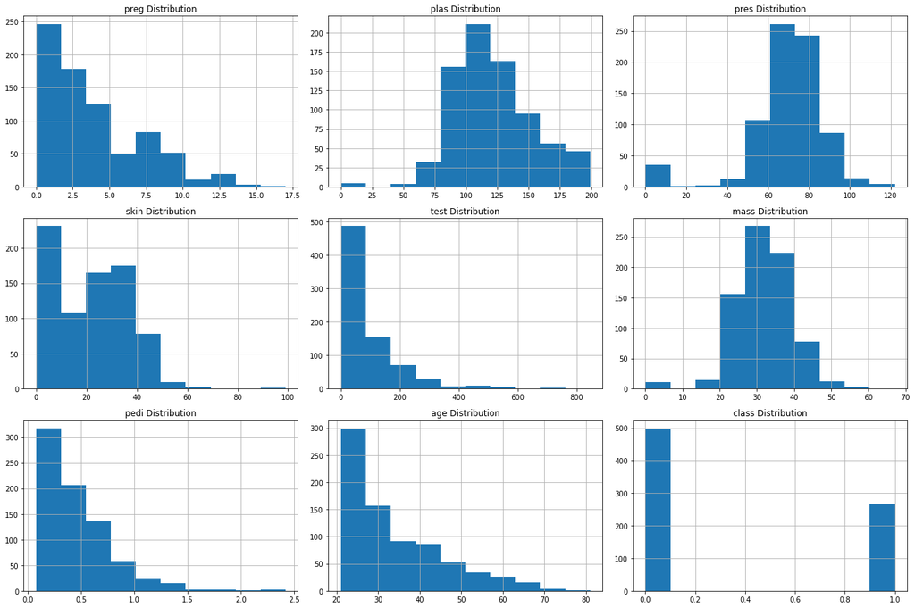

```python
from matplotlib import pyplot


### STUDENT CODE HERE
#print(data.columns)
def draw_histograms(df, variables, n_rows, n_cols):
    fig = pyplot.figure(figsize=(18,12))

    for i, var_name in enumerate(variables):
        ax = fig.add_subplot(n_rows, n_cols, i+1) # third parameter is position
        df[var_name].hist(bins=10)
        ax.set_title(var_name + " Distribution")
    fig.tight_layout() #improves appearance
    pyplot.show()

draw_histograms(data, data.columns, 3 ,3)



### STUDENT CODE until HERE
```

**Question: What can you tell from the histograms. Are they match the findings from the previous chapter**

Your answer: From histograms we can know 'count', 'min', 'max' and 'quantile' of the different classes. We can also tell wether the skew of each class ist positive or negative. The results match the previous description of data.

## Density Plots

In general a density plot works similar to a histogram. It gives you a smoother shape, since it uses an unlimited number of categories.

**Task: Find out how to draw a density plot and generate one for each variable.**

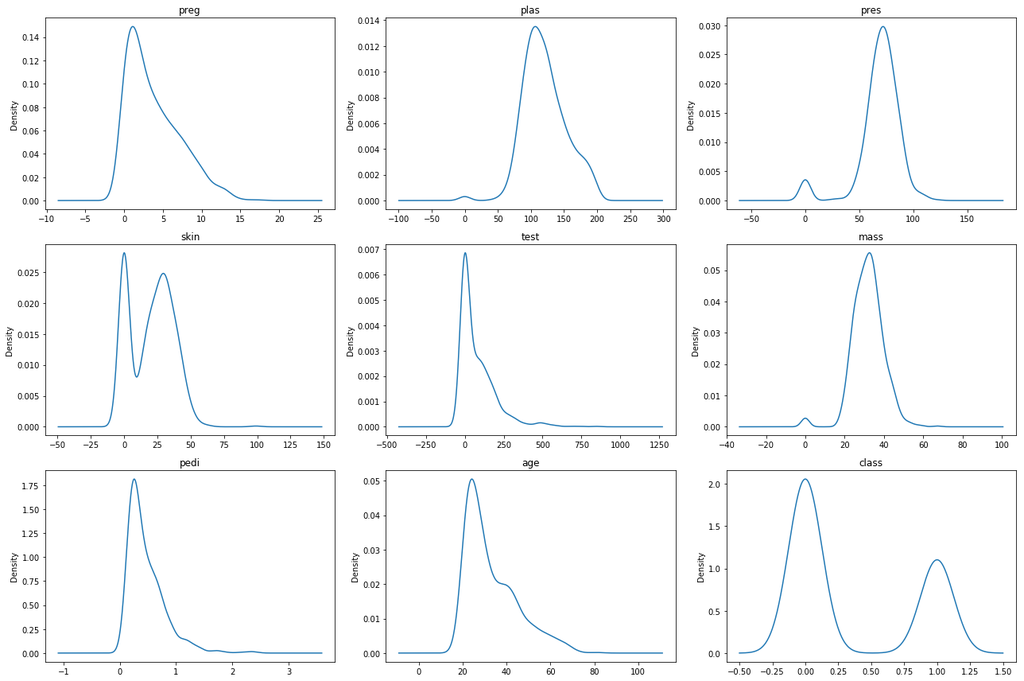

```python
### STUDENT CODE HERE

def draw_densitys(df, variables, n_rows, n_cols):
    fig = pyplot.figure(figsize=(18,12))

    for i, var_name in enumerate(variables):
        ax = fig.add_subplot(n_rows, n_cols, i+1) # third parameter is position
        df[var_name].plot.kde()
        ax.set_title(var_name)
    fig.tight_layout() #improves appearance
    pyplot.show()

draw_densitys(data, data.columns, 3 ,3)



### STUDENT CODE until HERE
```

## Box and Whisker Plots

Another way to visualize your data are so called *boxplots*. These look kind of unfamiliar at the first look, it shows a line for the median in a box, which starts at the 25th percentile and ends at 75th percentile. Another line shows the overall range of values (https://en.wikipedia.org/wiki/Box_plot).

The whiskers visualize the spread of the data and the dots symbolize the data values, which are 1.5 greater than the size of the middle 50% of the data.

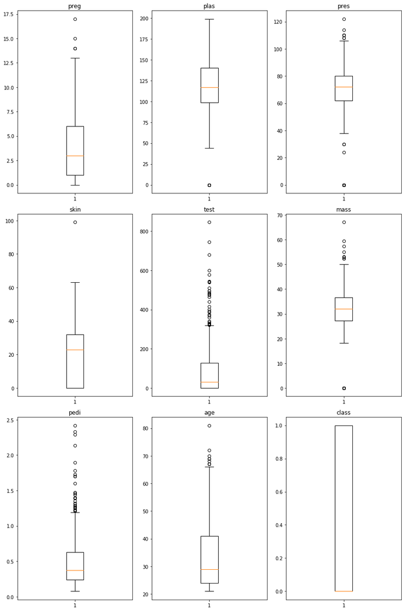

```python
### STUDENT CODE HERE
def draw_boxs(df, variables, n_rows, n_cols):
    fig = pyplot.figure(figsize=(12,18))

    for i, var_name in enumerate(variables):
        ax = fig.add_subplot(n_rows, n_cols, i+1) # third parameter is position
        pyplot.boxplot(data[var_name])
        ax.set_title(var_name)
    fig.tight_layout() #improves appearance
    pyplot.show()

draw_boxs(data, data.columns, 3 ,3)


### STUDENT CODE until HERE
```

## Multivariate plots

### Correlation Matrix plot

As we mentioned in chapter 2, the correlation describes the relationship between two variables. If you have already calculated the correlation matrix you can move on by visualizing it. This is useful to get a quick overview to analyze the correlation between all attributes. Moreover, it is important to spot highly correlated attributes, since some algorithms can suffer poor performance if there are highly correlated input values.

**Task: Create a heat map which gives you a good overview over the correlations**

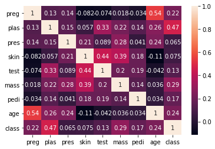

```
        preg   plas   pres   skin   test   mass   pedi    age  class
preg   1.000  0.129  0.141 -0.082 -0.074  0.018 -0.034  0.544  0.222
plas   0.129  1.000  0.153  0.057  0.331  0.221  0.137  0.264  0.467
pres   0.141  0.153  1.000  0.207  0.089  0.282  0.041  0.240  0.065
skin  -0.082  0.057  0.207  1.000  0.437  0.393  0.184 -0.114  0.075
test  -0.074  0.331  0.089  0.437  1.000  0.198  0.185 -0.042  0.131
mass   0.018  0.221  0.282  0.393  0.198  1.000  0.141  0.036  0.293
pedi  -0.034  0.137  0.041  0.184  0.185  0.141  1.000  0.034  0.174
age    0.544  0.264  0.240 -0.114 -0.042  0.036  0.034  1.000  0.238
class  0.222  0.467  0.065  0.075  0.131  0.293  0.174  0.238  1.000
```

```python
### STUDENT CODE HERE
import seaborn as sns

sns.heatmap(correlations, annot = correlations)

#plt.matshow(correlations, cmap = 'hot') --> if seaborn is not supposed to be used
#plt.xticks(range(len(correlations.columns)), correlations.columns)
#plt.yticks(range(len(correlations.columns)), correlations.columns)

### STUDENT CODE until HERE

pyplot.show()
print(correlations)
```

There you go, you are having a quick overview of the data.

### Scatter Plot Matrix

A scatter plot matrix is one of the last methods we present to you. The scatter plot represents the relationship between two variables as dots in two dimensions, one axis for each attribute. It is possible to plot a Scatter Plot for each attribute in your data, named *Scatter Plot Matrix*. One advantage of the Scatter Plot Matrix is that you can see structured relationships between some attributes, which might indicate correlation.

**Task: plot such a matrix**

**Question: Also describe what you can tell from the plot**

Your answer: There is not a very high correlation between most of the classes. There is a positive, linear association between skin and mass, plas and test and preg and age.

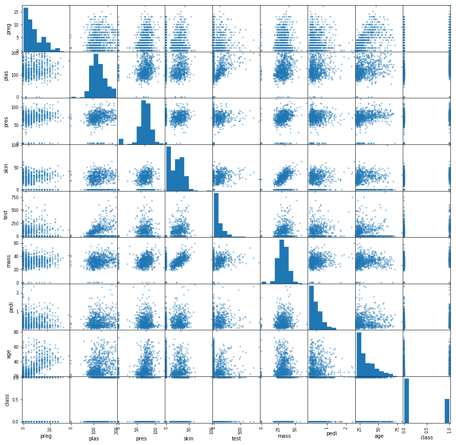

```python
from pandas.plotting import scatter_matrix

### STUDENT CODE HERE

scatter_matrix(data, figsize=(15,15))

### STUDENT CODE until HERE

pyplot.show()
```

# Scale Machine Learning data

Since we are now able to load and analyze our raw data, we are capable of the first big step in preparing our data. This step is to scale your data, because many self-learning approaches expect scaled data as input. In this chapter we will learn how to normalize and standardize data and when you have to choose normalizing over standardizing. This is especially important for artificial neural networks and deep learning.

## Normalize data

Normalizing should already sound familiar to you from your mathematics class. We shape the values into a range between 0 and 1. To realize this we have to know the maximum and the minimum value for each attribute. A simple option to do this, is to enumerate through the values.

**Task: Write a function `dataset_minmax()`, which calculates the minimum and maximum for each attribute.**

Hint: Your function takes the dataset as input and returns a list with a tuple (min, max) for each column in the dataset

```python
# Find the min and max values for each column
def dataset_minmax(dataset):

    ### STUDENT CODE HERE

    list_minmax = []
    for f in range(len(dataset[0])):
        minmax = (min(sub[f] for sub in dataset), max(sub[f] for sub in dataset))
        list_minmax.append(minmax)

    minmax = list_minmax

    ### STUDENT CODE until HERE
    return minmax


# small test dataset
dataset = [[50, 30], [20, 90]]
print(dataset)

# Calculate min and max for each column
minmax = dataset_minmax(dataset)
print(minmax)
```

```
[[50, 30], [20, 90]]
[(20, 50), (30, 90)]
```

Now we can get the minimum and maximum for each column. Using these values we can add a function, which normalizes our values based on the following formula:

$$scaled\, value = \frac{value - min}{max-min}$$

**Task: Implement this formula in a function, which is named: `normalize_dataset()`**

Hint: It takes the dataset and the minmax values and returns the normalized dataset.

```python
def normalize_dataset(dataset, minmax):

    return_dataset = list()


    ### STUDENT CODE HERE

    for l in range(len(dataset)):
        scaled = list()
        for k in range(len(dataset[0])):
            (min, max) = minmax[k]
            scaled.append((dataset[l][k]-min)/(max-min))
        return_dataset.append(scaled)

    ### STUDENT CODE until HERE

    return return_dataset
```

Now we got the necessary tools for normalizing our data. If we now put our functions together we can easily normalize our data.

```python
# Again a small test dataset
dataset = [[50, 30], [20, 90], [30, 40]]
print(dataset)

# Calculate min and max for each column
minmax = dataset_minmax(dataset)
print(minmax)

# Normalize columns
dataset = normalize_dataset(dataset, minmax)
print(dataset)
```

```
[[50, 30], [20, 90], [30, 40]]
[(20, 50), (30, 90)]
[[1.0, 0.0], [0.0, 1.0], [0.3333333333333333, 0.16666666666666666]]
```

Now we have to put it all together.

**Write a function called `load_normalized_csv`, which loads a CSV file and normalizes the data afterwards**

Hint: Your function takes the filename as input parameter and returns the normalized dataset.

```python
def load_normalized_csv(filename):

    ### STUDENT CODE HERE
    dataset = load_csv(filename)
    for i in range(len(dataset[0])):
        str_column_to_float(dataset, i)
    ### STUDENT CODE HERE
    minmax = dataset_minmax(dataset)
    dataset = normalize_dataset(dataset, minmax)
    return dataset
    ### STUDENT CODE until HERE

## Test:
filename = 'data/pima-indians-diabetes.csv'

dataset = load_normalized_csv(filename)

print(dataset[0])
```

```
[0.35294117647058826, 0.7437185929648241, 0.5901639344262295, 0.35353535353535354, 0.0, 0.5007451564828614, 0.23441502988898377, 0.48333333333333334, 1.0]
```

## Standardize data

First of all to standardize data we have to know the mean and standard deviation of the values for each column. Therefore we will start by writing a function, which calculates the mean value for each column based on the following formula:

$$mean = \frac{\sum\nolimits_{n=0}^N values}{count(values)}$$

**Task: Write a function which returns the mean value for each column.**

Hint: Your return type is a list with the mean for each column

```python
def column_means(dataset):

    means = list()

    ### STUDENT CODE HERE

    for h in range(len(dataset[0])):
        summe = 0
        for j in range(len(dataset)):
            summe += dataset[j][h]
        mean = summe/len(dataset)
        means.append(mean)

    ### STUDENT CODE until HERE

    return means
means = column_means(dataset)
```

As you may know from your probability classes, the standard deviation describes the average spread of the values from the mean. The following formula will help you write a function which calculates the standard deviation.

$$standard\, deviation = \sqrt[]{\frac{\sum\nolimits_{n=0}^N(value_i - mean)^2}{count(values) -1}}$$

**Task: Write a function which calculates the standard deviation for each column based on the given formula.**

Hint: Your return type is a list with the standard deviation for each column

```python
from math import sqrt

def column_stdevs(dataset, means):

    ### STUDENT CODE HERE

    stdevs = list()
    for i in range(len(dataset[0])):
        square_sum = 0
        for j in range(len(dataset)):
            square_sum += pow(dataset[j][i] - means[i], 2)
        standard_deviation = sqrt(square_sum / (len(dataset) - 1))
        stdevs.append(standard_deviation)

    ### STUDENT CODE until HERE

    return stdevs
```

Now we can est our mean and the standard deviations function in a little example:

```python
dataset = [[50, 30], [20, 90], [30, 50]]
print(dataset)

means = column_means(dataset)
print(means)

stdevs = column_stdevs(dataset, means)
print(stdevs)
```

```
[[50, 30], [20, 90], [30, 50]]
[33.333333333333336, 56.666666666666664]
[15.275252316519467, 30.550504633038933]
```

Now we are again at the point, where we have all required tools and can start with standardizing data.

**Task: Find a statistic method to standardize the values and write a function which does so.**

```python
def standardize_dataset(dataset, means, stdevs):
    return_dataset = list()

    ### STUDENT CODE HERE
    for i in range(len(dataset)):
        standardized = list()
        for j in range(len(dataset[0])):
            standardized.append((dataset[i][j] - means[j]) / stdevs[j])
        return_dataset.append(standardized)

    ### STUDENT CODE until HERE

    return return_dataset

#return_dataset = standardize_dataset(dataset, means, stdevs)
#print(return_dataset)
```

Now it is time to put it all together an give your standardization a try.

**Task: run all required functions and display your data in a histogram.**

```
[[50, 10, 30], [20, 25, 90], [30, 40, 50]]
[33.333333333333336, 25.0, 56.666666666666664]
[15.275252316519467, 15.0, 30.550504633038933]
[[1.0910894511799618, -1.0, -0.8728715609439694], [-0.8728715609439697, 0.0, 1.091089451179962], [-0.21821789023599253, 1.0, -0.2182178902359923]]
[[1.0910894511799618, -0.8728715609439697, -0.21821789023599253], [-1.0, 0.0, 1.0], [-0.8728715609439694, 1.091089451179962, -0.2182178902359923]]
```

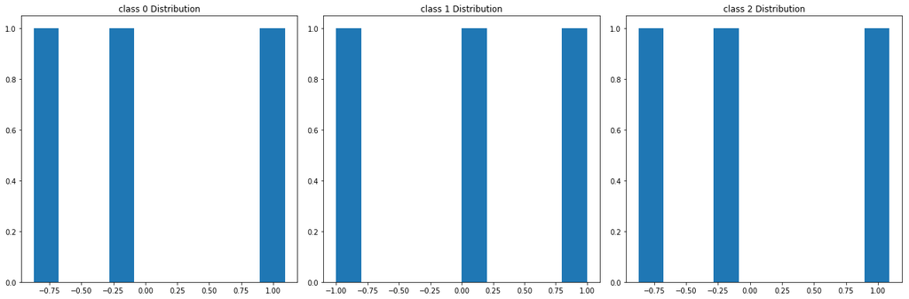

```python
dataset = [[50, 10, 30], [20, 25, 90], [30, 40, 50]]
print(dataset)

### STUDENT CODE HERE
from matplotlib import pyplot
means = column_means(dataset)
print(means)

stdevs = column_stdevs(dataset, means)
print(stdevs)

standardizations = standardize_dataset(dataset, means, stdevs)
print(standardizations)

# Transpose of list
standardizations_T = list()
for i in range(len(standardizations[0])):
    dataset_temp = list()
    for j in range(len(standardizations)):
        dataset_temp.append(standardizations[j][i])
    standardizations_T.append(dataset_temp)

print(standardizations_T)

# draw histogram
fig = pyplot.figure(figsize=(18,6))

for i in range(len(standardizations_T)):
        ax = fig.add_subplot(1, 3, i+1) # third parameter is position
        pyplot.hist(x = standardizations_T[i], bins = 10)
        ax.set_title("class " + str(i) + " Distribution")
        fig.tight_layout() #improves appearance

pyplot.show()


### STUDENT CODE until HERE
```

**Question: Is your standardization working well?**

Your Answer: Yes, it works.

Ok. Now let us also create a function which reads a given CSV file and standardizes it.

**Task: Complete the `load_standardized_csv` function**

```python
def load_standardized_csv(filename):

    ### STUDENT CODE HERE
    dataset = load_csv(filename)
    for i in range(len(dataset[0])):
        str_column_to_float(dataset, i)
    means = column_means(dataset)
    stdevs = column_stdevs(dataset, means)
    return_dataset = standardize_dataset(dataset, means, stdevs)
    return return_dataset
    ### STUDENT CODE until HERE

## Test:
filename = 'data/pima-indians-diabetes.csv'

dataset = load_standardized_csv(filename)

print(dataset[0])
```

```
[0.6395304921176576, 0.8477713205896718, 0.14954329852954296, 0.9066790623472505, -0.692439324724129, 0.2038799072674717, 0.468186870229798, 1.4250667195933604, 1.3650063669598067]
```

## When to normalize and when to standardize?

Now that you know how to realize both methods, it is important to know which one has to be used. Standardization works if your data conforms to a normal distribution. If your data confirms with this, standardizing is the method of choice. If your data doesn't have a specific distribution you should consider to normalize it before you apply your machine learning algorithm.

You can also use many other data transformation methods. The idea behind this transformation is to expose the structure of your data to the learning algorithm in the best possible way. In some cases it might not be clear which transformation is the best to use. In this cases trial and error help to get kind of a feeling for transformations.

# Prepare your data for machine learning

This is the last chapter of the data preparation tutorial. As we learned in the previous chapter, it is a good idea to prepare your data in a way that exposes the unique structure of your data. Also we created a with simple python code, to go one step further we will now use the package *scikit-learn*. After completing this lesson we will be able to rescale, normalize, standardize and binarize your data.

The scikit-learn library contains two different standard approaches for transforming data.

**Question: Research and describe the difference.**

Your answer: The advantage of the Combined fit and transform method is, that you need less data (only one set) whereas for Fit and mupltiple transform you need at least two sets of data. However with the Combined fit and tranfsorm method it can be more difficult to detect errors in the used transformation.

*Fit and multiple transform:* This method first uses the fit() function on training data to find the internal parameters for the desired transformation. Afterwards these parameters can be used to transform different data sets via the transform() function.

*Combined fit and transform:* Here the fit() and the transform() function are used on the same data set.

## Rescale data

In many cases your raw data is comprised with many different attributes, which however have many different scales. For common machine learning optimization algorithms it is important to rescale your data to certain ranges.

With scikit-learn you can use the `MinMaxScaler` class to rescale your attributes.

**Task: Rescale the data from the diabetes example with scikit-learn, by using `MinMaxScaler` and print the first eight rows of the rescaled dataset**

```python
# Rescale data (between 0 and 1)
from pandas import read_csv
from sklearn.preprocessing import MinMaxScaler

filename = 'data/pima-indians-diabetes.csv'
names = ['preg', 'plas', 'pres', 'skin', 'test', 'mass', 'pedi', 'age', 'class']

### STUDENT CODE HERE
data = read_csv(filename, names=names)
data = data.astype(float)
scaler = MinMaxScaler(copy=True,feature_range=(0,1))
data_minmax = scaler.fit_transform(data)
print(data_minmax[:8])

### STUDENT CODE until HERE
```

```
[[0.35294118 0.74371859 0.59016393 0.35353535 0.         0.50074516
  0.23441503 0.48333333 1.        ]
 [0.05882353 0.42713568 0.54098361 0.29292929 0.         0.39642325
  0.11656704 0.16666667 0.        ]
 [0.47058824 0.91959799 0.52459016 0.         0.         0.34724292
  0.25362938 0.18333333 1.        ]
 [0.05882353 0.44723618 0.54098361 0.23232323 0.11111111 0.41877794
  0.03800171 0.         0.        ]
 [0.         0.68844221 0.32786885 0.35353535 0.19858156 0.64232489
  0.94363792 0.2        1.        ]
 [0.29411765 0.58291457 0.60655738 0.         0.         0.38152012
  0.05251921 0.15       0.        ]
 [0.17647059 0.3919598  0.40983607 0.32323232 0.10401891 0.46199702
  0.07258753 0.08333333 1.        ]
 [0.58823529 0.57788945 0.         0.         0.         0.52608048
  0.02391119 0.13333333 0.        ]]
```

## Standardize data

You can standardize data by using the `StandardScaler` class in scikit-learn.

**Task: Standardize the diabetes example by using the `StandardScaler` and print the first 5 rows of the dataset**

```python
from sklearn.preprocessing import StandardScaler

### STUDENT CODE HERE
scaler = StandardScaler()
data_standardize = scaler.fit_transform(data)
print(data_standardize[:5])
### STUDENT CODE until HERE
```

```
[[ 0.63994726  0.84832379  0.14964075  0.90726993 -0.69289057  0.20401277
   0.46849198  1.4259954   1.36589591]
 [-0.84488505 -1.12339636 -0.16054575  0.53090156 -0.69289057 -0.68442195
  -0.36506078 -0.19067191 -0.73212021]
 [ 1.23388019  1.94372388 -0.26394125 -1.28821221 -0.69289057 -1.10325546
   0.60439732 -0.10558415  1.36589591]
 [-0.84488505 -0.99820778 -0.16054575  0.15453319  0.12330164 -0.49404308
  -0.92076261 -1.04154944 -0.73212021]
 [-1.14185152  0.5040552  -1.50468724  0.90726993  0.76583594  1.4097456
   5.4849091  -0.0204964   1.36589591]]
```

## Normalize data

**Task: Normalize the diabetes example, by using the Normalizer class and print the first 5 rows of your dataset**

```python
# Normalize data (length of 1)
from sklearn.preprocessing import Normalizer

### STUDENT CODE HERE

data_normalizer = Normalizer().fit_transform(data)
print(data_normalizer[:5])

### STUDENT CODE until HERE
```

```
[[0.03355185 0.82761219 0.40262215 0.1957191  0.         0.18789033
  0.00350617 0.27959871 0.00559197]
 [0.008424   0.71604034 0.55598426 0.24429612 0.         0.22407851
  0.00295683 0.26114412 0.        ]
 [0.04039717 0.9240852  0.32317734 0.         0.         0.11765675
  0.00339336 0.16158867 0.00504965]
 [0.00661199 0.58846737 0.43639153 0.15207584 0.62152733 0.185797
  0.0011042  0.13885185 0.        ]
 [0.         0.59638065 0.17412574 0.15236002 0.73132809 0.18762048
  0.00995999 0.14365373 0.00435314]]
```

## Binarize data

A new method to pre-process data is binarization. As you might guess you can set a threshold and every value above it will be assigned the value one and values equal or below the threshold will be assigned the value 0. With scikit-learn you can use the class `Binarizer`.

**Task: Binarize the diabetes example and give the first 5 rows**

```python
from sklearn.preprocessing import Binarizer

### STUDENT CODE HERE
data_binarize = Binarizer().fit_transform(data)
print(data_binarize[:5])
### STUDENT CODE until HERE
```

```
[[1. 1. 1. 1. 0. 1. 1. 1. 1.]
 [1. 1. 1. 1. 0. 1. 1. 1. 0.]
 [1. 1. 1. 0. 0. 1. 1. 1. 1.]
 [1. 1. 1. 1. 1. 1. 1. 1. 0.]
 [0. 1. 1. 1. 1. 1. 1. 1. 1.]]
```

# Wrap up

In this session you have seen how you can properly read, understand and prepare data. This is a very important step before learning approaches comes into play. Remember that your algorithm can only perform well, if you have proper data!

**Task: Summarize briefly what methods you have learned today. For better understanding go ahead and plot the output of each preparation method (also the combination of multiple). Also describe the plots briefly.**

# Summerization

We have learned how to load a dataset and convert its datatype. We are also able to get a quick overview of our data using pandas functions. For example we can read out some of the key attributes of our data, we can see how it correlates within itself and we can sort our data by attributes.

In order to get a better insight on our data, we can use 'matplotlib' to visualize our data in Histograms, Density plots, Boxplots, heat maps or scatter matrixes. Also, as preparation for Machine Learning, we can now rescale, normalize and standardize our data or we can use scikit-learn packages to rescale the data to different structures.

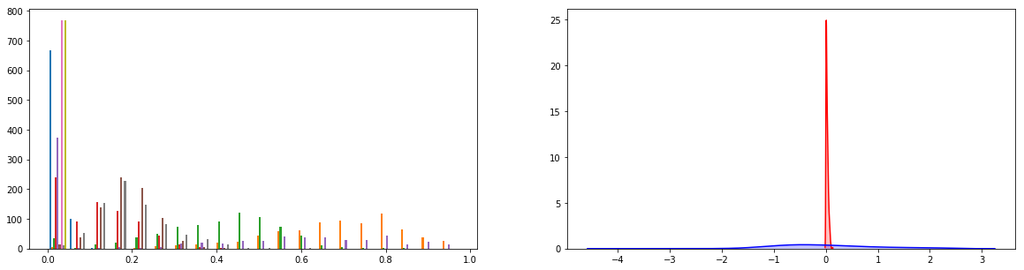

```python
#Histogram of data_normalizer
import numpy as np
import matplotlib.pyplot as plt
import seaborn as sns

fig = plt.figure(figsize=(20,5))

ax1 = fig.add_subplot(1, 2, 1)
ax1.hist(data_normalizer, bins=20)

ax2 = fig.add_subplot(1, 2, 2)
sns.kdeplot(data_normalizer.T[0], shade=True, color="r")
sns.kdeplot(data_standardize.T[1], shade=True, color="b")
plt.show()
```

The left plot shows the normalization of a dataset consisting of several columns. The right plot shows the difference of normalizing and standardizing data.

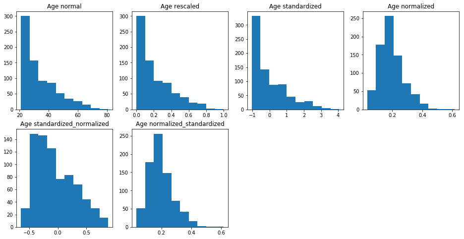

```python
filename = 'data/pima-indians-diabetes.csv'
names = ['preg', 'plas', 'pres', 'skin', 'test', 'mass', 'pedi', 'age', 'class']

data = read_csv(filename, names=names)
data = data.astype(float)

plt.figure(figsize=[16,8])

normal = plt.subplot(2, 4, 1)
normal.hist(data['age'])
normal.set_title('Age normal')

scaler = MinMaxScaler(copy=True,feature_range=(0,1))
data_minmax = scaler.fit_transform(data)
rescaled = plt.subplot(2, 4, 2)
rescaled.hist(data_minmax[:,7])
rescaled.set_title('Age rescaled')

data_standardized = StandardScaler().fit_transform(data)
standardized = plt.subplot(2, 4, 3)
standardized.hist(data_standardized[:,7])
standardized.set_title('Age standardized')

data_normalized = Normalizer().fit_transform(data)
normalized = plt.subplot(2, 4, 4)
normalized.hist(data_normalized[:,7])
normalized.set_title('Age normalized')

data_standardized_normalized = Normalizer().fit_transform(data_standardized)
standardized_normalized = plt.subplot(2, 4, 5)
standardized_normalized.hist(data_standardized_normalized[:,7])
standardized_normalized.set_title('Age standardized_normalized')

data_normalized_standardized = Normalizer().fit_transform(data_normalized)
normalized_standardized = plt.subplot(2, 4, 6)
normalized_standardized.hist(data_normalized_standardized[:,7])
normalized_standardized.set_title('Age normalized_standardized')

pyplot.show()
```